# Permutation Test for WGCNA Connectivity Loss

# WGCNA Modules for Control Genes

Build modules from control genes using CTRL samples only, mirroring how the DEG modules were constructed.

```r
datExpr_ctrl_only <- datExpr_control[which(true_labels == "CTRL"), ]
adj_ctrl_control <- adjacency(datExpr_ctrl_only, power = SOFT_POWER, type = "signed")
ctrl_tree <- hclust(as.dist(1 - adj_ctrl_control), method = "average")
invisible(capture.output(
  ctrl_control_modules <- cutreeDynamic(
    dendro = ctrl_tree,
    distM = 1 - adj_ctrl_control,
    deepSplit = 4,
    minClusterSize = 10
  )
))
control_module_colors_raw <- labels2colors(ctrl_control_modules)

# Remap WGCNA standard colors to non-clashing names with matching hex
ctrl_color_remap <- c(
  turquoise = "sky",
  blue      = "peach",
  brown     = "jade",
  yellow    = "coral",
  green     = "lavender",
  black     = "umber",
  red       = "mustard",
  pink      = "rose",
  magenta   = "aqua",
  purple    = "spring",
  grey      = "grey"
)
# Hex codes for plotting (keyed by new name)
ctrl_color_hex <- c(
  sky      = "#5DA5DA",
  peach    = "#FAA43A",
  jade     = "#60BD68",
  coral    = "#F15854",
  lavender = "#B276B2",
  umber    = "#8D4B08",
  mustard  = "#DECF3F",
  rose     = "#F17CB0",
  aqua     = "#66E3D9",
  spring   = "#00FF7F",
  grey     = "grey"
)

control_module_colors <- ctrl_color_remap[control_module_colors_raw]
names(control_module_colors) <- control_genes

cat("Control modules found:", length(unique(ctrl_control_modules[ctrl_control_modules != 0])), "\n")
```

```
## Control modules found: 10
```

```r
cat("Unassigned (grey):", sum(ctrl_control_modules == 0), "of", length(ctrl_control_modules), "\n\n")
```

```
## Unassigned (grey): 10 of 218
```

```r
tibble(module = control_module_colors) |>
  filter(module != "grey") |>
  count(module, sort = TRUE) |>
  print()
```

```
## # A tibble: 10 × 2
##    module       n
##    <chr>    <int>
##  1 sky         38
##  2 peach       31
##  3 jade        22
##  4 coral       21
##  5 lavender    19
##  6 mustard     18
##  7 umber       18
##  8 rose        16
##  9 aqua        15
## 10 spring      10
```

## Bootstrap Support (LFP) for Control Modules

Quantify module stability using the same bootstrap resampling approach as the DEG modules (step 05). Resample CTRL samples with replacement 1000 times, rebuild the network each time, and compute the Largest Fragment Proportion (LFP) per module.

```r
N_BOOT <- 1000

# Reference module assignments (numeric, excluding grey)
ctrl_ref_modules <- data.frame(
  gene = control_genes,
  module = ctrl_control_modules,
  color = control_module_colors,
  stringsAsFactors = FALSE
)

boot_results <- vector("list", N_BOOT)

for (b in seq_len(N_BOOT)) {
  n_samp <- nrow(datExpr_ctrl_only)
  boot_idx <- sample(n_samp, n_samp, replace = TRUE)
  expr_boot <- datExpr_ctrl_only[boot_idx, ]

  # Match original control module construction:
  # adjacency + hclust + cutreeDynamic
  adj_boot <- adjacency(expr_boot, power = SOFT_POWER,
                         type = "signed")
  tree_boot <- hclust(as.dist(1 - adj_boot),
                       method = "average")
  invisible(capture.output(
    mods_boot <- cutreeDynamic(
      dendro = tree_boot,
      distM = 1 - adj_boot,
      deepSplit = 4,
      minClusterSize = 10
    )
  ))

  boot_results[[b]] <- data.frame(
    gene = colnames(expr_boot),
    module = mods_boot,
    stringsAsFactors = FALSE
  )
}

# Compute LFP per module
ctrl_modules_list <- unique(
  ctrl_ref_modules$module[ctrl_ref_modules$module != 0]
)

ctrl_lfp <- map_dfr(ctrl_modules_list, function(mod) {
  mod_genes <- ctrl_ref_modules$gene[ctrl_ref_modules$module == mod]
  mod_color <- ctrl_ref_modules$color[ctrl_ref_modules$module == mod][1]

  lfp_vals <- sapply(boot_results, function(boot) {
    boot_sub <- boot[boot$gene %in% mod_genes, ]
    counts <- table(boot_sub$module)
    counts_nz <- counts[names(counts) != "0"]
    if (length(counts_nz) == 0) return(0)
    max(counts_nz) / length(mod_genes)
  })

  tibble(
    module = mod,
    color = mod_color,
    n_genes = length(mod_genes),
    mean_lfp = mean(lfp_vals),
    sd_lfp = sd(lfp_vals),
    se_lfp = sd(lfp_vals) / sqrt(N_BOOT)
  )
})

cat("=== CONTROL MODULE BOOTSTRAP SUPPORT ===\n")
```

```
## === CONTROL MODULE BOOTSTRAP SUPPORT ===
```

```r
print(ctrl_lfp |> arrange(desc(mean_lfp)))
```

```
## # A tibble: 10 × 6
##    module color    n_genes mean_lfp sd_lfp  se_lfp
##     <dbl> <chr>      <int>    <dbl>  <dbl>   <dbl>
##  1      3 jade          22    0.886  0.124 0.00393
##  2      2 peach         31    0.768  0.144 0.00456
##  3      6 mustard       18    0.703  0.189 0.00597
##  4      4 coral         21    0.703  0.176 0.00555
##  5      9 aqua          15    0.622  0.175 0.00554
##  6      8 rose          16    0.613  0.145 0.00457
##  7      7 umber         18    0.591  0.184 0.00582
##  8      5 lavender      19    0.582  0.141 0.00446
##  9     10 spring        10    0.476  0.269 0.00850
## 10      1 sky           38    0.469  0.134 0.00425
```

## GO Enrichment for Control Modules

Run GO biological process enrichment on the control modules using the same approach as the WGCNA perturbation pipeline (step 07), then reduce redundant terms with rrvgo.

```r
library(clusterProfiler)
library(rrvgo)
library(AnnotationHub)

TERM2GENE <- readRDS(here("data", "TERM2GENE.rds"))
TERM2NAME <- readRDS(here("data", "TERM2NAME.rds"))

# Universe = all genes in the full expression matrix
ctrl_universe <- rownames(full_expr_mat)

# Gene lists per control module (excluding grey)
ctrl_gene_lists <- split(
  names(control_module_colors[control_module_colors != "grey"]),
  control_module_colors[control_module_colors != "grey"]
)

cat("Control modules for GO:", length(ctrl_gene_lists), "\n")
```

```
## Control modules for GO: 10
```

```r
cat("Module sizes:", paste(names(ctrl_gene_lists),
    sapply(ctrl_gene_lists, length), sep = "=", collapse = ", "), "\n")
```

```
## Module sizes: aqua=15, coral=21, jade=22, lavender=19, mustard=18, peach=31, rose=16, sky=38, spring=10, umber=18
```

```r
# Enrichment function
ctrl_ego <- function(x) {
  enricher(
    gene = x,
    pvalueCutoff = 0.05,
    pAdjustMethod = "none",
    universe = ctrl_universe,
    minGSSize = 10,
    maxGSSize = 500,
    qvalueCutoff = 0.2,
    TERM2GENE = TERM2GENE[TERM2GENE$GO %in% TERM2NAME[["BP"]]$go_id, ],
    TERM2NAME = TERM2NAME[["BP"]]
  )
}

# Run compareCluster
ctrl_compGO <- compareCluster(
  geneCluster = ctrl_gene_lists,
  fun = ctrl_ego
)

ctrl_go_results <- as.data.frame(ctrl_compGO@compareClusterResult) |>
  dplyr::rename(module_color = Cluster) |>
  arrange(module_color, pvalue)

cat("Total enriched BP terms:", nrow(ctrl_go_results), "\n")
```

```
## Total enriched BP terms: 490
```

```r
cat("Terms per module:\n")
```

```
## Terms per module:
```

```r
print(table(ctrl_go_results$module_color))
```

```
##
##     aqua    coral     jade lavender  mustard    peach     rose      sky
##       30      101       23       28       49       61       31       85
##   spring    umber
##       49       33
```

```r
# rrvgo semantic reduction
ah <- AnnotationHub()
org.Zm.eg.db <- ah[["AH119718"]]

ctrl_go_filtered <- ctrl_go_results |>
  filter(Count > 1) |>
  group_by(module_color) |>
  arrange(pvalue, .by_group = TRUE) |>
  ungroup()

ctrl_go_ids <- unique(ctrl_go_results$ID)
if (length(ctrl_go_ids) > 1) {
  simMatrix <- calculateSimMatrix(
    ctrl_go_ids,
    orgdb = org.Zm.eg.db,
    ont = "BP",
    method = "Rel"
  )
  scores <- setNames(-log10(ctrl_go_results$pvalue), ctrl_go_results$ID)
  reducedTerms <- reduceSimMatrix(
    simMatrix, scores, threshold = 0.7, orgdb = org.Zm.eg.db
  )
  ctrl_go_rrvgo <- ctrl_go_filtered |>
    filter(ID %in% reducedTerms$parent)
} else {
  ctrl_go_rrvgo <- ctrl_go_filtered
}

# Top 1 BP term per control module
ctrl_top_bp <- ctrl_go_rrvgo |>
  group_by(module_color) |>
  slice_min(pvalue, n = 1, with_ties = FALSE) |>
  ungroup() |>
  dplyr::select(module_color, ID, Description, pvalue, Count)

cat("\nTop BP term per control module:\n")
```

```
##
## Top BP term per control module:
```

```r
print(ctrl_top_bp)
```

```
## # A tibble: 10 × 5
##    module_color ID         Description                              pvalue Count
##    <fct>        <chr>      <chr>                                     <dbl> <int>
##  1 aqua         GO:0009658 chloroplast organization                1.07e-2     2
##  2 coral        GO:0030388 fructose 1,6-bisphosphate metabolic pr… 4.15e-7     3
##  3 jade         GO:0009112 nucleobase metabolic process            1.40e-3     2
##  4 lavender     GO:0000413 protein peptidyl-prolyl isomerization   3.91e-3     2
##  5 mustard      GO:0030388 fructose 1,6-bisphosphate metabolic pr… 7.03e-5     2
##  6 peach        GO:0006551 leucine metabolic process               2.42e-4     2
##  7 rose         GO:0009642 response to light intensity             2.96e-3     2
##  8 sky          GO:0022900 electron transport chain                1.60e-9     9
##  9 spring       GO:0046148 pigment biosynthetic process            1.79e-3     2
## 10 umber        GO:0022900 electron transport chain                2.62e-6     5
```

## Module Size Comparison

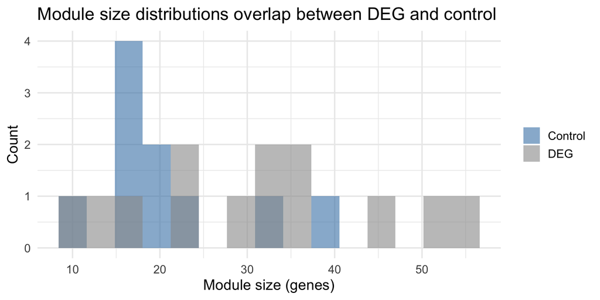

```r
deg_sizes <- tibble(
  module = module_colors,
  type = "DEG"
) |>
  filter(module != "grey", !is.na(module)) |>
  count(module, type, name = "n_genes")

ctrl_sizes <- tibble(
  module = control_module_colors,
  type = "Control"
) |>
  filter(module != "grey") |>
  count(module, type, name = "n_genes")

bind_rows(deg_sizes, ctrl_sizes) |>
  ggplot(aes(x = n_genes, fill = type)) +
  geom_histogram(bins = 15, alpha = 0.6, position = "identity") +
  scale_fill_manual(values = c(DEG = "grey60", Control = "steelblue")) +
  theme_minimal(base_size = 14) +
  labs(x = "Module size (genes)", y = "Count", fill = NULL,
       title = "Module size distributions overlap between DEG and control")
```

# Helper Function

```r
compute_module_delta_k <- function(datExpr_a, datExpr_b, power, mod_colors) {
  adj_a <- adjacency(datExpr_a, power = power, type = "signed")
  adj_b <- adjacency(datExpr_b, power = power, type = "signed")

  k_a <- intramodularConnectivity(adj_a, mod_colors)
  k_b <- intramodularConnectivity(adj_b, mod_colors)

  delta_kWithin <- k_b$kWithin - k_a$kWithin
  delta_kOut    <- k_b$kOut - k_a$kOut

  module_ids <- unique(mod_colors[mod_colors != "grey" & !is.na(mod_colors)])
  list(
    kWithin = sapply(module_ids, function(m) {
      idx <- which(mod_colors == m)
      mean(delta_kWithin[idx], na.rm = TRUE)
    }),
    kOut = sapply(module_ids, function(m) {
      idx <- which(mod_colors == m)
      mean(delta_kOut[idx], na.rm = TRUE)
    })
  )
}

# Density ridgeline panel constructor (used by kWithin sections)
# points_df must have columns: module, z_observed, fdr
# fill_color: single color string OR named vector (module -> hex)
# go_terms: optional named vector (module -> GO description) for y-axis labels
make_density_panel <- function(density_df, points_df, panel_title,
                               fill_color = "identity",
                               go_terms = NULL,
                               module_sizes = NULL) {
  # Build y-axis labels with module size: "green (n=30)"
  mod_levels <- levels(density_df$module)
  if (!is.null(module_sizes)) {
    y_labels <- sapply(mod_levels, function(m) {
      n <- module_sizes[m]
      if (!is.na(n)) sprintf("%s\n(n=%d)", m, n) else m
    })
  } else {
    y_labels <- setNames(mod_levels, mod_levels)
  }

  if (fill_color[1] == "identity") {
    p <- ggplot(density_df, aes(x = z_value, y = module, fill = module)) +
      geom_density_ridges(color = "grey40", alpha = 0.7,
                          scale = 0.9, rel_min_height = 0.01) +
      scale_fill_identity() +
      guides(fill = "none")
  } else if (length(fill_color) == 1) {
    p <- ggplot(density_df, aes(x = z_value, y = module)) +
      geom_density_ridges(fill = fill_color, color = "grey40", alpha = 0.7,
                          scale = 0.9, rel_min_height = 0.01)
  } else {
    p <- ggplot(density_df, aes(x = z_value, y = module, fill = module)) +
      geom_density_ridges(color = "grey40", alpha = 0.7,
                          scale = 0.9, rel_min_height = 0.01) +
      scale_fill_manual(values = fill_color) +
      guides(fill = "none")
  }
  p <- p +
    geom_vline(xintercept = 0, linetype = "dashed", color = "grey50") +
    geom_segment(
      data = points_df,
      aes(x = z_observed, xend = z_observed,
          y = as.numeric(module),
          yend = as.numeric(module) + 0.8),
      color = "red", linewidth = 0.8, inherit.aes = FALSE
    ) +
    geom_text(
      data = points_df |> filter(fdr < 0.05),
      aes(x = z_observed - 0.6, y = as.numeric(module) + 0.35,
          label = sprintf("%.3f", fdr)),
      color = "red", size = 3, hjust = 0.5, inherit.aes = FALSE
    ) +
    scale_y_discrete(labels = y_labels) +
    scale_x_continuous(limits = c(NA, 5),
                       breaks = seq(-10, 10, 2),
                       minor_breaks = seq(-10, 10, 2)) +
    theme_minimal(base_size = 14) +
    labs(y = NULL, x = expression(Z[Delta * k]), title = panel_title)

  # GO annotations inside plot area, right-aligned at x = 2.5
  if (!is.null(go_terms)) {
    go_df <- tibble(
      module = names(go_terms),
      go_desc = unname(go_terms)
    ) |>
      filter(module %in% levels(density_df$module)) |>
      mutate(
        module = factor(module, levels = levels(density_df$module)),
        y_pos = as.numeric(module) + 0.35
      )
    p <- p +
      geom_text(
        data = go_df,
        aes(x = 2.5, y = y_pos, label = go_desc),
        hjust = 0, size = 14 * 0.8 / .pt, fontface = "italic",
        inherit.aes = FALSE
      )
  }

  p
}
```

# Observed Delta kWithin

```r
ctrl_idx  <- which(true_labels == "CTRL")
inv4m_idx <- which(true_labels == "Inv4m")

obs_deg <- compute_module_delta_k(
  datExpr_all[ctrl_idx, ], datExpr_all[inv4m_idx, ],
  SOFT_POWER, module_colors
)
observed_delta     <- obs_deg$kWithin
observed_delta_out <- obs_deg$kOut

obs_ctrl <- compute_module_delta_k(
  datExpr_control[ctrl_idx, ], datExpr_control[inv4m_idx, ],
  SOFT_POWER, control_module_colors
)
observed_control     <- obs_ctrl$kWithin
observed_control_out <- obs_ctrl$kOut

cat("Observed mean delta kWithin per DEG module:\n")
```

```
## Observed mean delta kWithin per DEG module:
```

```r
print(round(sort(observed_delta), 4))
```

```
##         tan       brown        blue      yellow        pink      purple
##     -3.0065     -2.3642     -1.6366     -1.4675     -1.3624     -1.1055
##       black greenyellow       green         red      salmon   turquoise
##     -0.8012     -0.6313     -0.6115     -0.5079     -0.3888     -0.2768
##     magenta
##     -0.1432
```

```r
cat("\nObserved mean delta kOut per DEG module:\n")
```

```
##
## Observed mean delta kOut per DEG module:
```

```r
print(round(sort(observed_delta_out), 4))
```

```
##        pink      purple      yellow greenyellow       brown       black
##     -1.5068     -1.3451     -0.7252     -0.4355     -0.3494      0.2222
##        blue     magenta         red         tan   turquoise       green
##      0.2779      0.7208      0.8851      1.0936      1.1145      1.5777
##      salmon
##      1.6231
```

```r
cat("\nObserved mean delta kWithin per control module:\n")
```

```
##
## Observed mean delta kWithin per control module:
```

```r
print(round(sort(observed_control), 4))
```

```
##      sky    peach lavender    umber     jade     aqua     rose  mustard
##  -9.8194  -4.3318  -4.1815  -3.7793  -3.0502  -2.8169  -2.0236  -1.8069
##    coral   spring
##  -1.2086  -0.0044
```

```r
cat("\nObserved mean delta kOut per control module:\n")
```

```
##
## Observed mean delta kOut per control module:
```

```r
print(round(sort(observed_control_out), 4))
```

```
##     aqua lavender      sky     rose    umber  mustard     jade    peach
## -14.1508 -12.7947 -11.4968  -8.1628  -7.6495  -6.0226  -1.7706  -1.3583
##    coral   spring
##   0.2292   4.7928
```

# Module Label Permutation: Is the Fine Structure Real?

Before testing connectivity *change*, we first verify that the modules capture real coexpression structure in the CTRL network. We keep the adjacency matrix fixed and shuffle module labels 1000 times. If observed mean $k_{Within}$ exceeds the shuffled null, the modules are more internally connected than random gene groupings of the same sizes.

```r
N_LABEL_PERM <- 1000

# --- DEG modules in CTRL network ---
adj_ctrl_deg_full <- adjacency(
  datExpr_all[ctrl_idx, ],
  power = SOFT_POWER, type = "signed"
)

# Observed kWithin per DEG module
k_obs_deg <- intramodularConnectivity(
  adj_ctrl_deg_full, module_colors
)
obs_kw_deg <- sapply(
  unique(module_colors[module_colors != "grey" &
                        !is.na(module_colors)]),
  function(m) {
    mean(k_obs_deg$kWithin[module_colors == m],
         na.rm = TRUE)
  }
)

# Null: shuffle module labels, keep sizes
null_kw_deg <- matrix(NA, nrow = N_LABEL_PERM,
                       ncol = length(obs_kw_deg))
colnames(null_kw_deg) <- names(obs_kw_deg)

for (i in seq_len(N_LABEL_PERM)) {
  shuffled <- sample(module_colors)
  names(shuffled) <- names(module_colors)
  k_shuf <- intramodularConnectivity(
    adj_ctrl_deg_full, shuffled
  )
  null_kw_deg[i, ] <- sapply(names(obs_kw_deg), function(m) {
    mean(k_shuf$kWithin[shuffled == m], na.rm = TRUE)
  })
}

# P-values: fraction of null >= observed
pvals_label_deg <- sapply(names(obs_kw_deg), function(m) {
  mean(null_kw_deg[, m] >= obs_kw_deg[m])
})

cat("=== DEG MODULE STRUCTURE TEST ===\n")
```

```
## === DEG MODULE STRUCTURE TEST ===
```

```r
cat("Observed kWithin vs label-shuffled null (CTRL network)\n\n")
```

```
## Observed kWithin vs label-shuffled null (CTRL network)
```

```r
deg_structure <- tibble(
  module = names(obs_kw_deg),
  n_genes = sapply(names(obs_kw_deg),
    function(m) sum(module_colors == m, na.rm = TRUE)),
  observed_kWithin = round(obs_kw_deg, 3),
  null_mean = round(colMeans(null_kw_deg), 3),
  null_sd = round(apply(null_kw_deg, 2, sd), 3),
  p_value = pvals_label_deg
) |> arrange(p_value)
print(deg_structure)
```

```
## # A tibble: 13 × 6
##    module      n_genes observed_kWithin null_mean null_sd p_value
##    <chr>         <int>            <dbl>     <dbl>   <dbl>   <dbl>
##  1 pink             30            1.72      0.167   0.074   0
##  2 black            32            1.34      0.179   0.071   0
##  3 green            36            1.58      0.207   0.076   0
##  4 magenta          24            0.766     0.135   0.064   0
##  5 turquoise        55            1.02      0.314   0.089   0
##  6 greenyellow      16            0.937     0.09    0.059   0
##  7 purple           22            1.38      0.124   0.066   0
##  8 red              34            0.886     0.194   0.073   0
##  9 blue             51            1.86      0.291   0.085   0
## 10 yellow           36            1.67      0.204   0.075   0
## 11 brown            46            2.82      0.266   0.085   0
## 12 tan              12            3.58      0.063   0.052   0
## 13 salmon           11            0.446     0.06    0.052   0.001
```

```r
# --- Control modules in CTRL network ---
adj_ctrl_ctrl_full <- adjacency(
  datExpr_control[ctrl_idx, ],
  power = SOFT_POWER, type = "signed"
)

k_obs_ctrl <- intramodularConnectivity(
  adj_ctrl_ctrl_full, control_module_colors
)
obs_kw_ctrl <- sapply(
  unique(control_module_colors[
    control_module_colors != "grey"]),
  function(m) {
    mean(k_obs_ctrl$kWithin[
      control_module_colors == m], na.rm = TRUE)
  }
)

null_kw_ctrl <- matrix(NA, nrow = N_LABEL_PERM,
                        ncol = length(obs_kw_ctrl))
colnames(null_kw_ctrl) <- names(obs_kw_ctrl)

for (i in seq_len(N_LABEL_PERM)) {
  shuffled <- sample(control_module_colors)
  names(shuffled) <- names(control_module_colors)
  k_shuf <- intramodularConnectivity(
    adj_ctrl_ctrl_full, shuffled
  )
  null_kw_ctrl[i, ] <- sapply(
    names(obs_kw_ctrl), function(m) {
      mean(k_shuf$kWithin[shuffled == m], na.rm = TRUE)
    }
  )
}

pvals_label_ctrl <- sapply(names(obs_kw_ctrl), function(m) {
  mean(null_kw_ctrl[, m] >= obs_kw_ctrl[m])
})

cat("\n=== CONTROL MODULE STRUCTURE TEST ===\n")
```

```
##
## === CONTROL MODULE STRUCTURE TEST ===
```

```r
cat("Observed kWithin vs label-shuffled null (CTRL network)\n\n")
```

```
## Observed kWithin vs label-shuffled null (CTRL network)
```

```r
ctrl_structure <- tibble(
  module = names(obs_kw_ctrl),
  n_genes = sapply(names(obs_kw_ctrl),
    function(m) sum(control_module_colors == m)),
  observed_kWithin = round(obs_kw_ctrl, 3),
  null_mean = round(colMeans(null_kw_ctrl), 3),
  null_sd = round(apply(null_kw_ctrl, 2, sd), 3),
  p_value = pvals_label_ctrl
) |> arrange(p_value)
print(ctrl_structure)
```

```
## # A tibble: 10 × 6
##    module   n_genes observed_kWithin null_mean null_sd p_value
##    <chr>      <int>            <dbl>     <dbl>   <dbl>   <dbl>
##  1 sky           38           18.0        4.50   0.949   0
##  2 lavender      19            8.30       2.20   0.672   0
##  3 mustard       18            9.50       2.08   0.696   0
##  4 rose          16            8.44       1.82   0.654   0
##  5 peach         31            7.08       3.66   0.84    0
##  6 jade          22            7.10       2.46   0.729   0
##  7 umber         18            5.10       2.07   0.716   0.001
##  8 aqua          15            3.92       1.74   0.634   0.006
##  9 coral         21            4.63       2.43   0.747   0.012
## 10 spring        10            0.567      1.07   0.495   0.872
```

```r
cat("\n=== SUMMARY ===\n")
```

```
##
## === SUMMARY ===
```

```r
cat("DEG modules with p < 0.05:",
    sum(pvals_label_deg < 0.05), "of",
    length(pvals_label_deg), "\n")
```

```
## DEG modules with p < 0.05: 13 of 13
```

```r
cat("Control modules with p < 0.05:",
    sum(pvals_label_ctrl < 0.05), "of",
    length(pvals_label_ctrl), "\n")
```

```
## Control modules with p < 0.05: 9 of 10
```

# Genotype Label Permutation Test

```r
null_deltas      <- matrix(NA, nrow = N_PERM, ncol = length(observed_delta))
null_deltas_out  <- matrix(NA, nrow = N_PERM, ncol = length(observed_delta_out))
colnames(null_deltas)     <- names(observed_delta)
colnames(null_deltas_out) <- names(observed_delta_out)

null_control     <- matrix(NA, nrow = N_PERM, ncol = length(observed_control))
null_control_out <- matrix(NA, nrow = N_PERM, ncol = length(observed_control_out))
colnames(null_control)     <- names(observed_control)
colnames(null_control_out) <- names(observed_control_out)

for (i in seq_len(N_PERM)) {
  perm_idx <- sample(n_total)
  pseudo_ctrl  <- perm_idx[1:n_ctrl]
  pseudo_inv4m <- perm_idx[(n_ctrl + 1):n_total]

  perm_deg <- compute_module_delta_k(
    datExpr_all[pseudo_ctrl, ], datExpr_all[pseudo_inv4m, ],
    SOFT_POWER, module_colors
  )
  null_deltas[i, ]     <- perm_deg$kWithin
  null_deltas_out[i, ] <- perm_deg$kOut

  perm_ctrl <- compute_module_delta_k(
    datExpr_control[pseudo_ctrl, ], datExpr_control[pseudo_inv4m, ],
    SOFT_POWER, control_module_colors
  )
  null_control[i, ]     <- perm_ctrl$kWithin
  null_control_out[i, ] <- perm_ctrl$kOut

}
```

# Results

## ECDF P-values

One-tailed test: fraction of permuted values $\leq$ observed (testing for connectivity loss more extreme than the null).

```r
# kWithin
ecdf_pvals <- sapply(names(observed_delta), function(m) {
  mean(null_deltas[, m] <= observed_delta[m])
})
ecdf_pvals_control <- sapply(names(observed_control), function(m) {
  mean(null_control[, m] <= observed_control[m])
})

# kOut (one-tailed: test for gain in inter-modular connectivity)
ecdf_pvals_out <- sapply(names(observed_delta_out), function(m) {
  mean(null_deltas_out[, m] >= observed_delta_out[m])
})
ecdf_pvals_control_out <- sapply(
  names(observed_control_out), function(m) {
    mean(null_control_out[, m] >= observed_control_out[m])
  }
)
```

### DEG Modules

```r
results_deg <- tibble(
  module = names(observed_delta),
  type = "DEG",
  n_genes = sapply(names(observed_delta), function(m) sum(module_colors == m, na.rm = TRUE)),
  observed_mean_delta_k = round(observed_delta, 4),
  null_mean = round(colMeans(null_deltas), 4),
  null_sd = round(apply(null_deltas, 2, sd), 4),
  ecdf_pvalue = round(ecdf_pvals, 4)
) |>
  arrange(ecdf_pvalue)

results_deg
```

```
## # A tibble: 13 × 7
##    module      type  n_genes observed_mean_delta_k null_mean null_sd ecdf_pvalue
##    <chr>       <chr>   <int>                 <dbl>     <dbl>   <dbl>       <dbl>
##  1 brown       DEG        46                -2.36    -0.0942   0.602      0
##  2 tan         DEG        12                -3.01    -0.0647   0.967      0.0012
##  3 purple      DEG        22                -1.11    -0.0511   0.435      0.0059
##  4 blue        DEG        51                -1.64    -0.100    0.640      0.0069
##  5 pink        DEG        30                -1.36    -0.0676   0.575      0.0106
##  6 yellow      DEG        36                -1.47    -0.0906   0.736      0.0333
##  7 salmon      DEG        11                -0.389   -0.0206   0.275      0.0921
##  8 greenyellow DEG        16                -0.631   -0.0296   0.463      0.104
##  9 red         DEG        34                -0.508   -0.0678   0.386      0.130
## 10 black       DEG        32                -0.801   -0.0694   0.653      0.132
## 11 green       DEG        36                -0.612   -0.0898   0.652      0.21
## 12 magenta     DEG        24                -0.143   -0.0495   0.268      0.366
## 13 turquoise   DEG        55                -0.277   -0.139    1.04       0.438
```

### Control Modules

```r
results_ctrl <- tibble(
  module = names(observed_control),
  type = "control",
  n_genes = sapply(names(observed_control), function(m) sum(control_module_colors == m)),
  observed_mean_delta_k = round(observed_control, 4),
  null_mean = round(colMeans(null_control), 4),
  null_sd = round(apply(null_control, 2, sd), 4),
  ecdf_pvalue = round(ecdf_pvals_control, 4)
) |>
  arrange(ecdf_pvalue)

results_ctrl
```

```
## # A tibble: 10 × 7
##    module   type    n_genes observed_mean_delta_k null_mean null_sd ecdf_pvalue
##    <chr>    <chr>     <int>                 <dbl>     <dbl>   <dbl>       <dbl>
##  1 lavender control      19               -4.18     -0.0489   2.42       0.0375
##  2 aqua     control      15               -2.82     -0.062    1.82       0.0483
##  3 jade     control      22               -3.05     -0.0742   2.19       0.096
##  4 umber    control      18               -3.78     -0.0472   2.81       0.0962
##  5 sky      control      38               -9.82      0.0081   8.00       0.126
##  6 mustard  control      18               -1.81     -0.0498   1.63       0.138
##  7 peach    control      31               -4.33     -0.093    3.69       0.162
##  8 coral    control      21               -1.21     -0.0638   1.40       0.216
##  9 rose     control      16               -2.02     -0.0004   2.53       0.244
## 10 spring   control      10               -0.0044   -0.0246   0.264      0.526
```

### BH FDR Correction Across All Tests

```r
all_results <- bind_rows(results_deg, results_ctrl)

all_results <- all_results |>
  mutate(
    fdr = p.adjust(ecdf_pvalue, method = "BH"),
    sig = ifelse(fdr < 0.05, "*", "")
  ) |>
  arrange(ecdf_pvalue)

cat("Significant at FDR < 0.05:\n")
```

```
## Significant at FDR < 0.05:
```

```r
all_results |>
  filter(fdr < 0.05) |>
  dplyr::select(module, type, n_genes, observed_mean_delta_k, ecdf_pvalue, fdr) |>
  print()
```

```
## # A tibble: 5 × 6
##   module type  n_genes observed_mean_delta_k ecdf_pvalue    fdr
##   <chr>  <chr>   <int>                 <dbl>       <dbl>  <dbl>
## 1 brown  DEG        46                 -2.36      0      0
## 2 tan    DEG        12                 -3.01      0.0012 0.0138
## 3 purple DEG        22                 -1.11      0.0059 0.0397
## 4 blue   DEG        51                 -1.64      0.0069 0.0397
## 5 pink   DEG        30                 -1.36      0.0106 0.0488
```

```r
cat("\nAll control modules:\n")
```

```
##
## All control modules:
```

```r
all_results |>
  filter(type == "control") |>
  dplyr::select(module, n_genes, observed_mean_delta_k, ecdf_pvalue, fdr) |>
  print()
```

```
## # A tibble: 10 × 5
##    module   n_genes observed_mean_delta_k ecdf_pvalue   fdr
##    <chr>      <int>                 <dbl>       <dbl> <dbl>
##  1 lavender      19               -4.18        0.0375 0.123
##  2 aqua          15               -2.82        0.0483 0.139
##  3 jade          22               -3.05        0.096  0.199
##  4 umber         18               -3.78        0.0962 0.199
##  5 sky           38               -9.82        0.126  0.199
##  6 mustard       18               -1.81        0.138  0.199
##  7 peach         31               -4.33        0.162  0.220
##  8 coral         21               -1.21        0.216  0.262
##  9 rose          16               -2.02        0.244  0.281
## 10 spring        10               -0.0044      0.526  0.526
```

## Save Results

```r
write_csv(all_results,
          file.path(OUTPUT_DIR,
                    "permutation_delta_kWithin_results.csv"))
saveRDS(
  list(
    observed = observed_delta,
    observed_control = observed_control,
    observed_out = observed_delta_out,
    observed_control_out = observed_control_out,
    null = null_deltas,
    null_control = null_control,
    null_out = null_deltas_out,
    null_control_out = null_control_out,
    pvals = ecdf_pvals,
    pvals_control = ecdf_pvals_control,
    pvals_out = ecdf_pvals_out,
    pvals_control_out = ecdf_pvals_control_out,
    control_genes = control_genes,
    control_module_colors = control_module_colors,
    photo_genes = photo_control,
    sag_genes = sag_control
  ),
  file.path(OUTPUT_DIR, "permutation_delta_kWithin.rds")
)
```

# Visualization

## Permutation Null Distributions

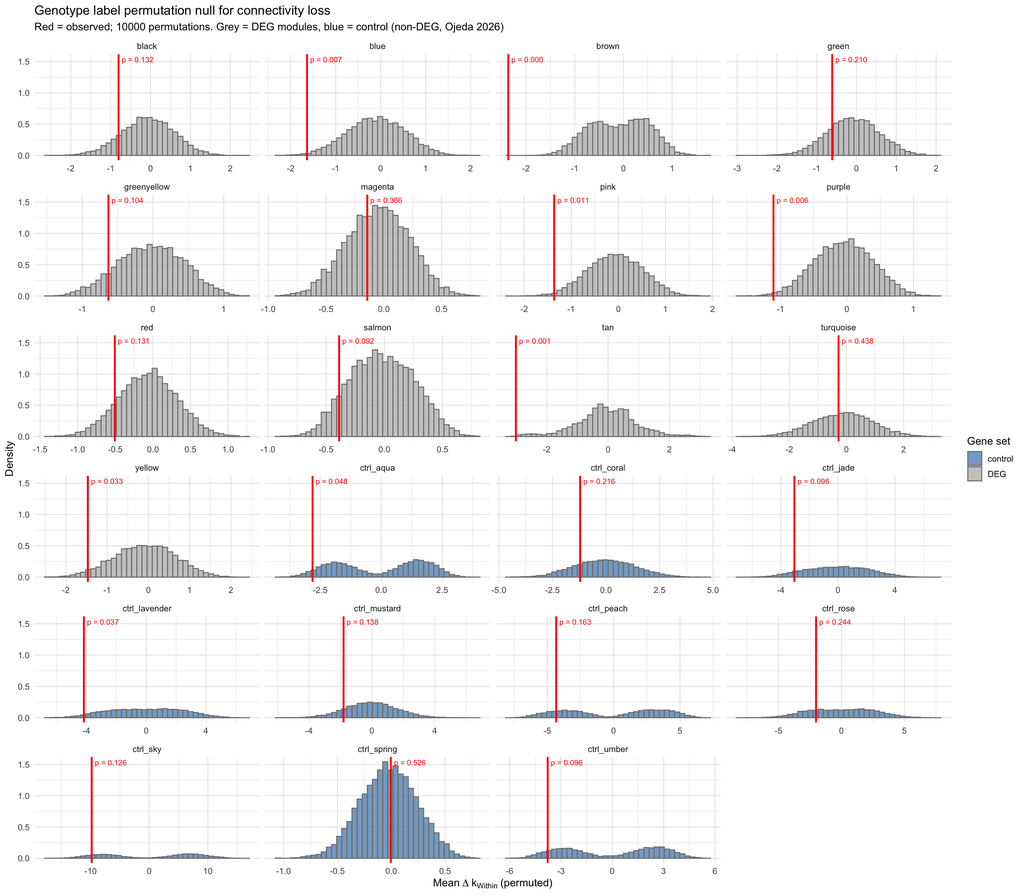

```r
# DEG modules
plot_deg <- map_dfr(names(observed_delta), function(m) {
  tibble(module = m, type = "DEG", null_value = null_deltas[, m])
})
# Control modules (prefix to avoid color name collisions)
plot_ctrl <- map_dfr(names(observed_control), function(m) {
  tibble(module = paste0("ctrl_", m), type = "control", null_value = null_control[, m])
})
plot_data <- bind_rows(plot_deg, plot_ctrl)

obs_data <- tibble(
  module = c(names(observed_delta), paste0("ctrl_", names(observed_control))),
  type = c(rep("DEG", length(observed_delta)), rep("control", length(observed_control))),
  observed = c(observed_delta, observed_control),
  ecdf_pvalue = c(ecdf_pvals, ecdf_pvals_control)
)

module_levels <- c(sort(names(observed_delta)), sort(paste0("ctrl_", names(observed_control))))
plot_data$module <- factor(plot_data$module, levels = module_levels)
obs_data$module  <- factor(obs_data$module, levels = module_levels)

p_null <- ggplot(plot_data, aes(x = null_value)) +
  geom_histogram(
    aes(y = after_stat(density), fill = type),
    bins = 40, color = "grey50", alpha = 0.7
  ) +
  geom_vline(data = obs_data, aes(xintercept = observed),
             color = "red", linewidth = 1) +
  geom_text(
    data = obs_data,
    aes(x = observed, y = Inf, label = sprintf("p = %.3f", ecdf_pvalue)),
    vjust = 1.5, hjust = -0.1, color = "red", size = 3
  ) +
  scale_fill_manual(values = c(DEG = "grey70", control = "steelblue")) +
  facet_wrap(~module, scales = "free_x", ncol = 4) +
  theme_minimal(base_size = 12) +
  labs(
    x = expression(Mean ~ Delta ~ k[Within] ~ "(permuted)"),
    y = "Density",
    title = "Genotype label permutation null for connectivity loss",
    subtitle = sprintf(
      "Red = observed; %d permutations. Grey = DEG modules, blue = control (non-DEG, Ojeda 2026)",
      N_PERM
    ),
    fill = "Gene set"
  )

print(p_null)
```

```r
ggsave(file.path(OUTPUT_DIR, "permutation_null_delta_kWithin.pdf"),
       p_null, width = 16, height = 14)
ggsave(file.path(OUTPUT_DIR, "permutation_null_delta_kWithin.png"),
       p_null, width = 16, height = 14, dpi = 300)
```

## |logFC| vs Delta kWithin

Scatterplot of Inv4m expression effect size against connectivity change, for DEG and control genes separately.

```r
library(patchwork)

# Load DEG effects
effects <- read_csv(
  file.path(paths$intermediate, "predictor_effects_leaf_interaction_model.csv"),
  show_col_types = FALSE
)
inv4m_effects <- effects |>
  filter(grepl("Inv4m", predictor), !grepl(":", predictor)) |>
  dplyr::select(gene, logFC, adj.P.Val)

# Gene-level delta kWithin for DEGs
adj_ctrl_deg  <- adjacency(datExpr_all[ctrl_idx, ], power = SOFT_POWER, type = "signed")
adj_inv4m_deg <- adjacency(datExpr_all[inv4m_idx, ], power = SOFT_POWER, type = "signed")
k_ctrl_deg  <- intramodularConnectivity(adj_ctrl_deg, module_colors)
k_inv4m_deg <- intramodularConnectivity(adj_inv4m_deg, module_colors)

deg_dk <- tibble(
  gene = rownames(k_ctrl_deg),
  delta_kWithin = k_inv4m_deg$kWithin - k_ctrl_deg$kWithin,
  group = "DEG"
)

# Gene-level delta kWithin for control genes
adj_ctrl_c  <- adjacency(datExpr_control[ctrl_idx, ], power = SOFT_POWER, type = "signed")
adj_inv4m_c <- adjacency(datExpr_control[inv4m_idx, ], power = SOFT_POWER, type = "signed")
k_ctrl_c  <- intramodularConnectivity(adj_ctrl_c, control_module_colors)
k_inv4m_c <- intramodularConnectivity(adj_inv4m_c, control_module_colors)

ctrl_dk <- tibble(
  gene = names(control_module_colors),
  delta_kWithin = k_inv4m_c$kWithin - k_ctrl_c$kWithin,
  group = "Topology control"
)

# Merge with logFC and p-value
scatter_df <- bind_rows(deg_dk, ctrl_dk) |>
  left_join(inv4m_effects |> dplyr::select(gene, logFC, adj.P.Val), by = "gene") |>
  mutate(
    abs_logFC = abs(logFC),
    neg_log10p = -log10(adj.P.Val)
  ) |>
  filter(!is.na(logFC))

# Correlations per group
cor_logfc <- scatter_df |>
  group_by(group) |>
  summarise(
    rho = cor(abs_logFC, delta_kWithin, method = "spearman"),
    .groups = "drop"
  )
cor_pval <- scatter_df |>
  group_by(group) |>
  summarise(
    rho = cor(neg_log10p, delta_kWithin, method = "spearman"),
    .groups = "drop"
  )
cat("Spearman correlations (|logFC| vs delta_k):\n")
```

```
## Spearman correlations (|logFC| vs delta_k):
```

```r
print(cor_logfc)
```

```
## # A tibble: 2 × 2
##   group                rho
##   <chr>              <dbl>
## 1 DEG               0.162
## 2 Topology control -0.0178
```

```r
cat("\nSpearman correlations (-log10P vs delta_k):\n")
```

```
##
## Spearman correlations (-log10P vs delta_k):
```

```r
print(cor_pval)
```

```
## # A tibble: 2 × 2
##   group                rho
##   <chr>              <dbl>
## 1 DEG               0.0485
## 2 Topology control -0.0296
```

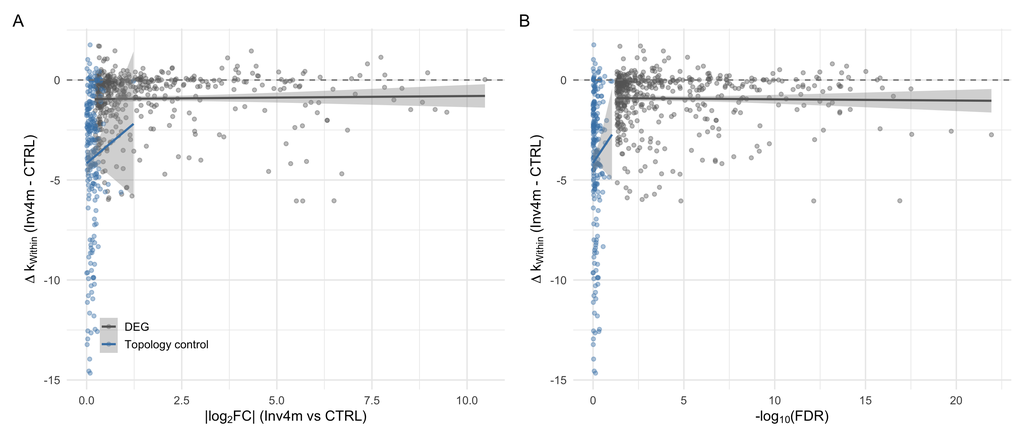

```r
# Panel A: |logFC| vs delta kWithin
p_logfc <- ggplot(scatter_df, aes(x = abs_logFC, y = delta_kWithin, color = group)) +
  geom_point(alpha = 0.4, size = 1.5) +
  geom_smooth(method = "lm", se = TRUE, linewidth = 1) +
  geom_hline(yintercept = 0, linetype = "dashed", color = "grey50") +
  scale_color_manual(values = c("DEG" = "grey40", "Topology control" = "steelblue")) +
  theme_minimal(base_size = 14) +
  labs(
    x = expression("|" * log[2] * "FC" * "| (Inv4m vs CTRL)"),
    y = expression(Delta ~ k[Within] ~ "(Inv4m - CTRL)"),
    color = NULL
  ) +
  theme(legend.position = c(0.2, 0.15))

# Panel B: -log10P vs delta kWithin
p_pval <- ggplot(scatter_df, aes(x = neg_log10p, y = delta_kWithin, color = group)) +
  geom_point(alpha = 0.4, size = 1.5) +
  geom_smooth(method = "lm", se = TRUE, linewidth = 1) +
  geom_hline(yintercept = 0, linetype = "dashed", color = "grey50") +
  scale_color_manual(values = c("DEG" = "grey40", "Topology control" = "steelblue")) +
  theme_minimal(base_size = 14) +
  labs(
    x = expression("-" * log[10] * "(FDR)"),
    y = expression(Delta ~ k[Within] ~ "(Inv4m - CTRL)"),
    color = NULL
  ) +
  theme(legend.position = "none")

p_combined <- p_logfc + p_pval + plot_annotation(tag_levels = "A")
print(p_combined)
```

```r
ggsave(file.path(OUTPUT_DIR, "logFC_pval_vs_delta_kWithin.pdf"),
       p_combined, width = 14, height = 6)
ggsave(file.path(OUTPUT_DIR, "logFC_pval_vs_delta_kWithin.png"),
       p_combined, width = 14, height = 6, dpi = 300)
```

### Linear model: does expression effect size predict connectivity loss?

If connectivity loss were an artifact of differential expression, |logFC| should be a strong predictor of $\Delta k_{Within}$. We fit gene-level linear models for DEG and control genes separately, and a combined model with an interaction term to test whether the relationship differs between groups.

```r
# DEG-only model
deg_only <- scatter_df |> filter(group == "DEG")
fit_deg <- lm(delta_kWithin ~ abs_logFC, data = deg_only)

cat("=== DEG genes: lm(delta_kWithin ~ |logFC|) ===\n")
```

```
## === DEG genes: lm(delta_kWithin ~ |logFC|) ===
```

```r
summary(fit_deg)
```

```
##
## Call:
## lm(formula = delta_kWithin ~ abs_logFC, data = deg_only)
##
## Residuals:
##     Min      1Q  Median      3Q     Max
## -5.1833 -0.4561  0.4889  0.8940  2.6496
##
## Coefficients:
##             Estimate Std. Error t value Pr(>|t|)
## (Intercept) -0.95453    0.08608 -11.088   <2e-16 ***
## abs_logFC    0.01514    0.03322   0.456    0.649
## ---
## Signif. codes:  0 '***' 0.001 '**' 0.01 '*' 0.05 '.' 0.1 ' ' 1
##
## Residual standard error: 1.389 on 463 degrees of freedom
## Multiple R-squared:  0.0004487,  Adjusted R-squared:  -0.00171
## F-statistic: 0.2078 on 1 and 463 DF,  p-value: 0.6487
```

```r
cat(sprintf("\nR² = %.4f  (|logFC| explains %.1f%% of variance in delta_k)\n",
            summary(fit_deg)$r.squared,
            summary(fit_deg)$r.squared * 100))
```

```
##
## R² = 0.0004  (|logFC| explains 0.0% of variance in delta_k)
```

```r
# Control-only model
ctrl_only <- scatter_df |> filter(group == "Topology control")
fit_ctrl <- lm(delta_kWithin ~ abs_logFC, data = ctrl_only)

cat("\n=== Topology control genes: lm(delta_kWithin ~ |logFC|) ===\n")
```

```
##
## === Topology control genes: lm(delta_kWithin ~ |logFC|) ===
```

```r
summary(fit_ctrl)
```

```
##
## Call:
## lm(formula = delta_kWithin ~ abs_logFC, data = ctrl_only)
##
## Residuals:
##     Min      1Q  Median      3Q     Max
## -10.639  -1.371   0.898   2.637   5.775
##
## Coefficients:
##             Estimate Std. Error t value Pr(>|t|)
## (Intercept)  -4.1642     0.3525 -11.813   <2e-16 ***
## abs_logFC     1.5978     1.6889   0.946    0.345
## ---
## Signif. codes:  0 '***' 0.001 '**' 0.01 '*' 0.05 '.' 0.1 ' ' 1
##
## Residual standard error: 3.533 on 216 degrees of freedom
## Multiple R-squared:  0.004127,   Adjusted R-squared:  -0.0004837
## F-statistic: 0.8951 on 1 and 216 DF,  p-value: 0.3452
```

```r
cat(sprintf("\nR² = %.4f  (|logFC| explains %.1f%% of variance in delta_k)\n",
            summary(fit_ctrl)$r.squared,
            summary(fit_ctrl)$r.squared * 100))
```

```
##
## R² = 0.0041  (|logFC| explains 0.4% of variance in delta_k)
```

```r
# Combined model with interaction
fit_interaction <- lm(delta_kWithin ~ abs_logFC * group, data = scatter_df)

cat("\n=== Combined: lm(delta_kWithin ~ |logFC| * group) ===\n")
```

```
##
## === Combined: lm(delta_kWithin ~ |logFC| * group) ===
```

```r
summary(fit_interaction)
```

```
##
## Call:
## lm(formula = delta_kWithin ~ abs_logFC * group, data = scatter_df)
##
## Residuals:
##      Min       1Q   Median       3Q      Max
## -10.6390  -0.6731   0.5274   1.0315   5.7751
##
## Coefficients:
##                                 Estimate Std. Error t value Pr(>|t|)
## (Intercept)                     -0.95453    0.14250  -6.699 4.42e-11 ***
## abs_logFC                        0.01514    0.05498   0.275    0.783
## groupTopology control           -3.20966    0.27005 -11.885  < 2e-16 ***
## abs_logFC:groupTopology control  1.58267    1.10044   1.438    0.151
## ---
## Signif. codes:  0 '***' 0.001 '**' 0.01 '*' 0.05 '.' 0.1 ' ' 1
##
## Residual standard error: 2.299 on 679 degrees of freedom
## Multiple R-squared:  0.2717, Adjusted R-squared:  0.2685
## F-statistic: 84.42 on 3 and 679 DF,  p-value: < 2.2e-16
```

```r
cat(sprintf("\nR² = %.4f\n", summary(fit_interaction)$r.squared))
```

```
##
## R² = 0.2717
```

## Effect Size Distribution: DEG vs Control

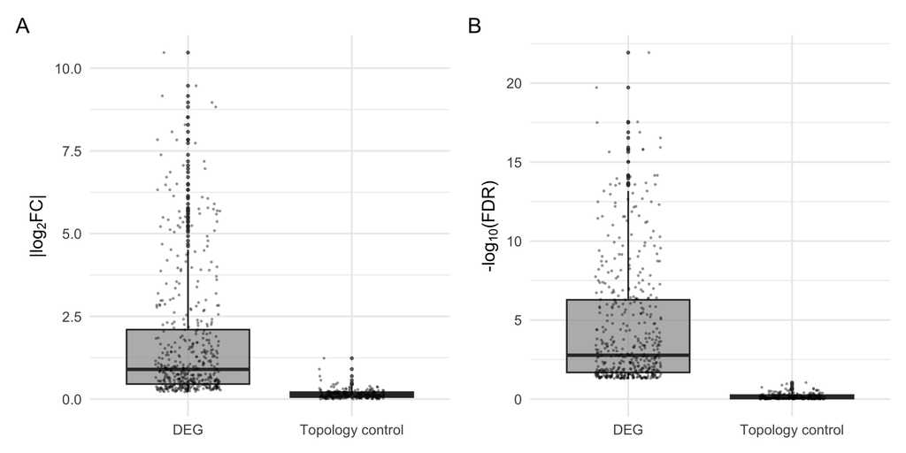

```r
# Panel A: |logFC|
p_box_logfc <- ggplot(scatter_df, aes(x = group, y = abs_logFC, fill = group)) +
  geom_boxplot(outlier.size = 0.8, alpha = 0.7) +
  geom_jitter(width = 0.2, size = 0.3, alpha = 0.3) +
  scale_fill_manual(values = c("Topology control" = "steelblue", "DEG" = "grey60")) +
  theme_minimal(base_size = 14) +
  theme(legend.position = "none") +
  labs(x = NULL, y = expression("|" * log[2] * "FC" * "|"))

# Panel B: -log10(FDR)
p_box_pval <- ggplot(scatter_df, aes(x = group, y = neg_log10p, fill = group)) +
  geom_boxplot(outlier.size = 0.8, alpha = 0.7) +
  geom_jitter(width = 0.2, size = 0.3, alpha = 0.3) +
  scale_fill_manual(values = c("Topology control" = "steelblue", "DEG" = "grey60")) +
  theme_minimal(base_size = 14) +
  theme(legend.position = "none") +
  labs(x = NULL, y = expression("-" * log[10] * "(FDR)"))

p_box_combined <- p_box_logfc + p_box_pval + plot_annotation(tag_levels = "A")
print(p_box_combined)
```

```r
wt_logfc <- wilcox.test(abs_logFC ~ group, data = scatter_df)
wt_pval  <- wilcox.test(neg_log10p ~ group, data = scatter_df)
cat("|logFC| Wilcoxon p:", format.pval(wt_logfc$p.value), "\n")
```

```
## |logFC| Wilcoxon p: < 2.22e-16
```

```r
cat("-log10(FDR) Wilcoxon p:", format.pval(wt_pval$p.value), "\n")
```

```
## -log10(FDR) Wilcoxon p: < 2.22e-16
```

```r
ggsave(file.path(OUTPUT_DIR, "effect_size_DEG_vs_control.pdf"),
       p_box_combined, width = 10, height = 5)
ggsave(file.path(OUTPUT_DIR, "effect_size_DEG_vs_control.png"),
       p_box_combined, width = 10, height = 5, dpi = 300)

ggsave(file.path(OUTPUT_DIR, "logFC_DEG_vs_control.pdf"),
       p_logfc, width = 5, height = 5)
ggsave(file.path(OUTPUT_DIR, "logFC_DEG_vs_control.png"),
       p_logfc, width = 5, height = 5, dpi = 300)
```

## Z-score Density Plot (Main Figure Candidate)

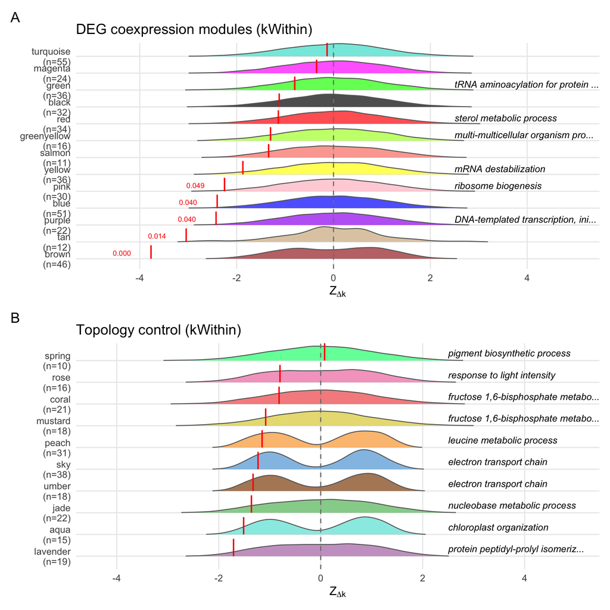

```r
# Load GO annotations for DEG modules
go_bp_file <- file.path(RUN_DIR, "07_module_annotation", "top_BP_per_module_rrvgo.csv")
if (file.exists(go_bp_file)) {
  go_bp <- read_csv(go_bp_file, show_col_types = FALSE)
  deg_go_terms <- setNames(
    str_trunc(go_bp$Description, 35),
    go_bp$module_color
  )
} else {
  deg_go_terms <- NULL
}

# Z-score the null distributions
deg_null_z <- perm_null_data <- null_deltas
deg_null_mean <- colMeans(null_deltas)
deg_null_sd <- apply(null_deltas, 2, sd)
for (m in colnames(deg_null_z)) {
  deg_null_z[, m] <- (deg_null_z[, m] - deg_null_mean[m]) / deg_null_sd[m]
}
deg_obs_z <- (observed_delta - deg_null_mean) / deg_null_sd

ctrl_null_z <- null_control
ctrl_null_mean <- colMeans(null_control)
ctrl_null_sd <- apply(null_control, 2, sd)
for (m in colnames(ctrl_null_z)) {
  ctrl_null_z[, m] <- (ctrl_null_z[, m] - ctrl_null_mean[m]) / ctrl_null_sd[m]
}
ctrl_obs_z <- (observed_control - ctrl_null_mean) / ctrl_null_sd

# DEG violin data
deg_violin <- map_dfr(colnames(deg_null_z), function(m) {
  tibble(module = m, z_value = deg_null_z[, m])
})
# Compute FDR across all kWithin modules (DEG + control)
# Use positional indexing to avoid duplicate name collisions
n_deg <- length(ecdf_pvals)
n_ctrl <- length(ecdf_pvals_control)
all_kw_pvals <- c(ecdf_pvals, ecdf_pvals_control)
all_kw_fdr <- p.adjust(all_kw_pvals, method = "BH")
kw_fdr_deg  <- setNames(all_kw_fdr[1:n_deg], names(ecdf_pvals))
kw_fdr_ctrl <- setNames(all_kw_fdr[(n_deg + 1):(n_deg + n_ctrl)], names(ecdf_pvals_control))

deg_points <- tibble(
  module = names(deg_obs_z),
  z_observed = deg_obs_z,
  fdr = kw_fdr_deg[names(deg_obs_z)]
)
deg_order <- deg_points |> arrange(z_observed) |> pull(module)
deg_violin$module <- factor(deg_violin$module, levels = deg_order)
deg_points$module <- factor(deg_points$module, levels = deg_order)

# Control violin data
ctrl_violin <- map_dfr(colnames(ctrl_null_z), function(m) {
  tibble(module = m, z_value = ctrl_null_z[, m])
})
ctrl_points <- tibble(
  module = names(ctrl_obs_z),
  z_observed = ctrl_obs_z,
  fdr = kw_fdr_ctrl[names(ctrl_obs_z)]
)
ctrl_order <- ctrl_points |> arrange(z_observed) |> pull(module)
ctrl_violin$module <- factor(ctrl_violin$module, levels = ctrl_order)
ctrl_points$module <- factor(ctrl_points$module, levels = ctrl_order)

# Module sizes for y-axis labels
deg_mod_sizes <- sapply(levels(deg_violin$module), function(m) {
  sum(module_colors == m, na.rm = TRUE)
})
ctrl_mod_sizes <- sapply(levels(ctrl_violin$module), function(m) {
  sum(control_module_colors == m)
})

p_deg_density <- make_density_panel(deg_violin, deg_points,
                                    "DEG coexpression modules (kWithin)",
                                    fill_color = "identity",
                                    go_terms = deg_go_terms,
                                    module_sizes = deg_mod_sizes)
# GO terms for control modules from enrichment
ctrl_go_annot <- setNames(
  str_trunc(ctrl_top_bp$Description, 35),
  ctrl_top_bp$module_color
)

p_ctrl_density <- make_density_panel(ctrl_violin, ctrl_points,
                                     "Topology control (kWithin)",
                                     fill_color = ctrl_color_hex,
                                     go_terms = ctrl_go_annot,
                                     module_sizes = ctrl_mod_sizes)

p_density_combined <- p_deg_density / p_ctrl_density +
  plot_annotation(tag_levels = "A")
print(p_density_combined)
```

```r
ggsave(file.path(OUTPUT_DIR, "zscore_density_DEG_vs_control.pdf"),
       p_density_combined, width = 10, height = 10)
ggsave(file.path(OUTPUT_DIR, "zscore_density_DEG_vs_control.png"),
       p_density_combined, width = 10, height = 10, dpi = 300)
```

## Z-score Density Plot: Inter-modular Connectivity (kOut)

Same approach as the kWithin plot but for extra-modular connectivity ($\Delta k_{Out}$). Positive values indicate genes gaining connections to genes outside their module in Inv4m.

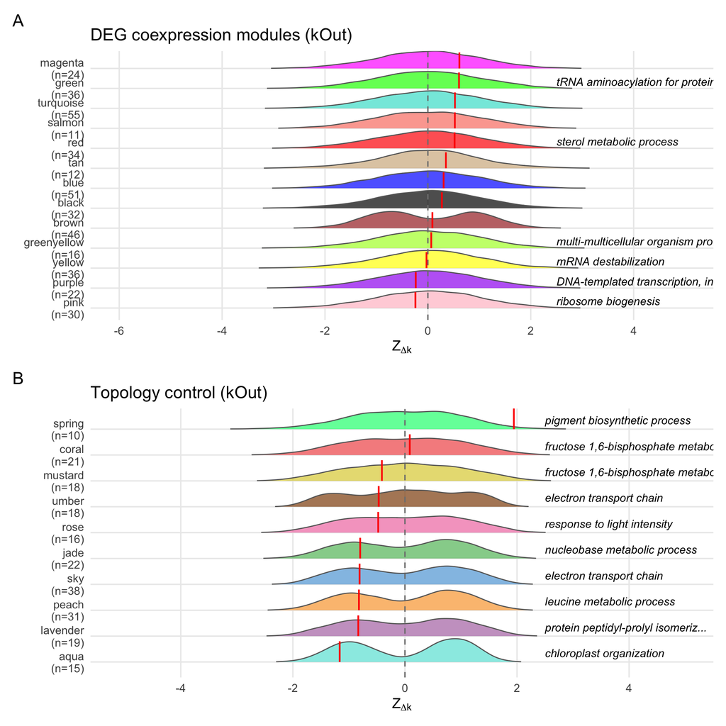

```r
# Z-score kOut null distributions
deg_null_z_out <- null_deltas_out
deg_null_mean_out <- colMeans(null_deltas_out)
deg_null_sd_out <- apply(null_deltas_out, 2, sd)
for (m in colnames(deg_null_z_out)) {
  deg_null_z_out[, m] <- (deg_null_z_out[, m] -
    deg_null_mean_out[m]) / deg_null_sd_out[m]
}
deg_obs_z_out <- (observed_delta_out -
  deg_null_mean_out) / deg_null_sd_out

ctrl_null_z_out <- null_control_out
ctrl_null_mean_out <- colMeans(null_control_out)
ctrl_null_sd_out <- apply(null_control_out, 2, sd)
for (m in colnames(ctrl_null_z_out)) {
  ctrl_null_z_out[, m] <- (ctrl_null_z_out[, m] -
    ctrl_null_mean_out[m]) / ctrl_null_sd_out[m]
}
ctrl_obs_z_out <- (observed_control_out -
  ctrl_null_mean_out) / ctrl_null_sd_out

# FDR across all kOut tests
n_deg_out <- length(ecdf_pvals_out)
n_ctrl_out <- length(ecdf_pvals_control_out)
all_kout_pvals <- c(ecdf_pvals_out, ecdf_pvals_control_out)
all_kout_fdr <- p.adjust(all_kout_pvals, method = "BH")
kout_fdr_deg <- setNames(
  all_kout_fdr[1:n_deg_out],
  names(ecdf_pvals_out)
)
kout_fdr_ctrl <- setNames(
  all_kout_fdr[(n_deg_out + 1):(n_deg_out + n_ctrl_out)],
  names(ecdf_pvals_control_out)
)

# DEG kOut density data
deg_violin_out <- map_dfr(colnames(deg_null_z_out), function(m) {
  tibble(module = m, z_value = deg_null_z_out[, m])
})
deg_points_out <- tibble(
  module = names(deg_obs_z_out),
  z_observed = deg_obs_z_out,
  fdr = kout_fdr_deg[names(deg_obs_z_out)]
)
deg_order_out <- deg_points_out |>
  arrange(z_observed) |>
  pull(module)
deg_violin_out$module <- factor(
  deg_violin_out$module, levels = deg_order_out
)
deg_points_out$module <- factor(
  deg_points_out$module, levels = deg_order_out
)

# Control kOut density data
ctrl_violin_out <- map_dfr(
  colnames(ctrl_null_z_out), function(m) {
    tibble(module = m, z_value = ctrl_null_z_out[, m])
  }
)
ctrl_points_out <- tibble(
  module = names(ctrl_obs_z_out),
  z_observed = ctrl_obs_z_out,
  fdr = kout_fdr_ctrl[names(ctrl_obs_z_out)]
)
ctrl_order_out <- ctrl_points_out |>
  arrange(z_observed) |>
  pull(module)
ctrl_violin_out$module <- factor(
  ctrl_violin_out$module, levels = ctrl_order_out
)
ctrl_points_out$module <- factor(
  ctrl_points_out$module, levels = ctrl_order_out
)

p_deg_kout <- make_density_panel(
  deg_violin_out, deg_points_out,
  "DEG coexpression modules (kOut)",
  fill_color = "identity",
  go_terms = deg_go_terms,
  module_sizes = deg_mod_sizes
)
p_ctrl_kout <- make_density_panel(
  ctrl_violin_out, ctrl_points_out,
  "Topology control (kOut)",
  fill_color = ctrl_color_hex,
  go_terms = ctrl_go_annot,
  module_sizes = ctrl_mod_sizes
)

p_kout_combined <- p_deg_kout / p_ctrl_kout +
  plot_annotation(tag_levels = "A")
print(p_kout_combined)
```

```r
ggsave(file.path(OUTPUT_DIR,
                 "zscore_density_kOut_DEG_vs_control.pdf"),
       p_kout_combined, width = 10, height = 10)
ggsave(file.path(OUTPUT_DIR,
                 "zscore_density_kOut_DEG_vs_control.png"),
       p_kout_combined, width = 10, height = 10, dpi = 300)
```

## kOut: CTRL vs Inv4m Gene-level Scatter

Analogous to Figure 4C (kWithin hub scatter) but for inter-modular connectivity. Each point is a gene; axes are kOut in CTRL vs kOut in Inv4m. Points above the diagonal gained inter-modular connectivity.

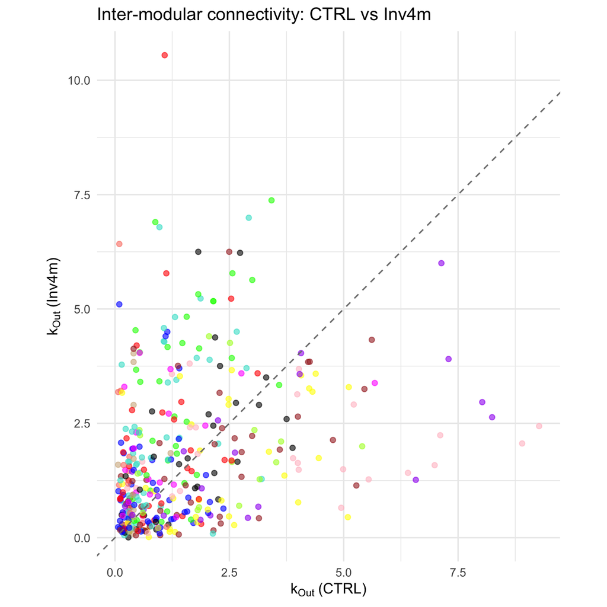

```r
# Gene-level kOut (already computed in logfc_vs_delta_k chunk)
kout_scatter <- tibble(
  gene = rownames(k_ctrl_deg),
  module = module_colors[rownames(k_ctrl_deg)],
  kOut_CTRL = k_ctrl_deg$kOut,
  kOut_Inv4m = k_inv4m_deg$kOut
) |>
  filter(module != "grey", !is.na(module))

p_kout_scatter <- ggplot(
  kout_scatter,
  aes(x = kOut_CTRL, y = kOut_Inv4m, color = module)
) +
  geom_point(alpha = 0.6, size = 2) +
  geom_abline(slope = 1, intercept = 0,
              linetype = "dashed", color = "grey50") +
  scale_color_identity() +
  theme_minimal(base_size = 14) +
  labs(
    x = expression(k[Out] ~ "(CTRL)"),
    y = expression(k[Out] ~ "(Inv4m)"),
    title = "Inter-modular connectivity: CTRL vs Inv4m"
  ) +
  coord_equal()

print(p_kout_scatter)
```

```r
# Summary stats
cat("Genes above diagonal (kOut gain):",
    sum(kout_scatter$kOut_Inv4m > kout_scatter$kOut_CTRL),
    "of", nrow(kout_scatter), "\n")
```

```
## Genes above diagonal (kOut gain): 218 of 405
```

```r
cat("Paired Wilcoxon (kOut Inv4m vs CTRL):\n")
```

```
## Paired Wilcoxon (kOut Inv4m vs CTRL):
```

```r
wt_kout <- wilcox.test(kout_scatter$kOut_Inv4m,
                        kout_scatter$kOut_CTRL,
                        paired = TRUE)
print(wt_kout)
```

```
##
##  Wilcoxon signed rank test with continuity correction
##
## data:  kout_scatter$kOut_Inv4m and kout_scatter$kOut_CTRL
## V = 46999, p-value = 0.01245
## alternative hypothesis: true location shift is not equal to 0
```

```r
ggsave(file.path(OUTPUT_DIR, "kOut_CTRL_vs_Inv4m_scatter.pdf"),
       p_kout_scatter, width = 8, height = 8)
ggsave(file.path(OUTPUT_DIR, "kOut_CTRL_vs_Inv4m_scatter.png"),
       p_kout_scatter, width = 8, height = 8, dpi = 300)
```

# Module Preservation (Langfelder 2011) and Combined Stats Table

Run `modulePreservation()` for both gene sets (CTRL → Inv4m) to get Z_summary, Z_density, and Z_connectivity. Then compile a single table with all statistics for the supplementary material.

```r
# --- DEG modules: load existing results from 06_preservation ---
# These were computed with power = 18 (the correct value)
mp_deg_file <- file.path(OUTPUT_DIR,
                          "modulePreservation_results.rds")
mp_deg <- readRDS(mp_deg_file)

z_deg <- mp_deg$preservation$Z$ref.CTRL$inColumnsAlsoPresentIn.Inv4m
deg_pres <- tibble(
  module = rownames(z_deg),
  Zsummary = round(z_deg[, "Zsummary.pres"], 2),
  Zdensity = round(z_deg[, "Zdensity.pres"], 2),
  Zconnectivity = round(z_deg[, "Zconnectivity.pres"], 2)
) |> filter(module != "gold", module != "grey")

cat("=== DEG MODULE PRESERVATION (from 06_preservation) ===\n")
```

```
## === DEG MODULE PRESERVATION (from 06_preservation) ===
```

```r
print(deg_pres |> arrange(Zsummary))
```

```
## # A tibble: 13 × 4
##    module      Zsummary Zdensity Zconnectivity
##    <chr>          <dbl>    <dbl>         <dbl>
##  1 salmon          1.2      0.66          1.74
##  2 tan             2.24     2.47          2.01
##  3 greenyellow     2.96     3.51          2.41
##  4 blue            3.11     1.86          4.37
##  5 red             3.31     4.41          2.2
##  6 yellow          3.49     2.58          4.4
##  7 purple          3.84     4.42          3.26
##  8 brown           3.85     3.93          3.77
##  9 black           4.51     5.07          3.95
## 10 green           5.01     7.82          2.21
## 11 magenta         5.33     7.74          2.92
## 12 pink            5.77     5.12          6.41
## 13 turquoise       6.05     6.52          5.59
```

```r
# --- Control modules: run modulePreservation ---
# NOTE: modulePreservation uses Pearson correlation internally.
# The joint analysis (TODO) will use power = 18 for both sets.
multiExpr_ctrl <- list(
  CTRL = list(data = datExpr_control[ctrl_idx, ]),
  Inv4m = list(data = datExpr_control[inv4m_idx, ])
)
multiColor_ctrl <- list(CTRL = control_module_colors)

mp_ctrl <- modulePreservation(
  multiData = multiExpr_ctrl,
  multiColor = multiColor_ctrl,
  referenceNetworks = 1,
  testNetworks = 2,
  nPermutations = 200,
  networkType = "signed",
  verbose = 0
)

z_ctrl <- mp_ctrl$preservation$Z$ref.CTRL$inColumnsAlsoPresentIn.Inv4m
ctrl_pres <- tibble(
  module = rownames(z_ctrl),
  Zsummary = round(z_ctrl[, "Zsummary.pres"], 2),
  Zdensity = round(z_ctrl[, "Zdensity.pres"], 2),
  Zconnectivity = round(z_ctrl[, "Zconnectivity.pres"], 2)
) |> filter(module != "gold", module != "grey")

cat("\n=== CONTROL MODULE PRESERVATION ===\n")
```

```
##
## === CONTROL MODULE PRESERVATION ===
```

```r
print(ctrl_pres |> arrange(Zsummary))
```

```
## # A tibble: 10 × 4
##    module   Zsummary Zdensity Zconnectivity
##    <chr>       <dbl>    <dbl>         <dbl>
##  1 spring       1.62     0.93          2.31
##  2 umber        1.84     1.4           2.27
##  3 aqua         2.38     1.26          3.49
##  4 rose         3.98     4.87          3.1
##  5 coral        4.11     3.53          4.69
##  6 lavender     4.36     4.51          4.21
##  7 peach        4.5      2.25          6.76
##  8 jade         4.7      4.48          4.93
##  9 mustard      5.04     5.25          4.83
## 10 sky          6.6      6.32          6.88
```

## Combined Statistics Table

```r
# Load DEG preservation summary for LFP values
preservation_summary <- read_csv(
  file.path(OUTPUT_DIR, "preservation_summary.csv"),
  show_col_types = FALSE
)

# DEG table
deg_table <- deg_pres |>
  left_join(
    tibble(
      module = names(observed_delta),
      delta_kWithin = round(observed_delta, 3),
      kWithin_FDR = round(kw_fdr_deg[names(observed_delta)], 4),
      delta_kOut = round(observed_delta_out, 3),
      kOut_FDR = round(kout_fdr_deg[names(observed_delta_out)], 4)
    ),
    by = "module"
  ) |>
  mutate(
    gene_set = "DEG",
    n_genes = sapply(module, function(m)
      sum(module_colors == m, na.rm = TRUE)),
    LFP = round(sapply(module, function(m) {
      pres_row <- preservation_summary[
        preservation_summary$color == m, ]
      if (nrow(pres_row) > 0) pres_row$ctrl_lfp[1]
      else NA_real_
    }), 3)
  )

# Control table
ctrl_table <- ctrl_pres |>
  left_join(
    tibble(
      module = names(observed_control),
      delta_kWithin = round(observed_control, 3),
      kWithin_FDR = round(
        kw_fdr_ctrl[names(observed_control)], 4),
      delta_kOut = round(observed_control_out, 3),
      kOut_FDR = round(
        kout_fdr_ctrl[names(observed_control_out)], 4)
    ),
    by = "module"
  ) |>
  mutate(
    gene_set = "Control",
    n_genes = sapply(module, function(m)
      sum(control_module_colors == m)),
    LFP = round(ctrl_lfp$mean_lfp[
      match(module, ctrl_lfp$color)], 3)
  )

# Combine
combined_table <- bind_rows(deg_table, ctrl_table) |>
  dplyr::select(
    gene_set, module, n_genes, LFP,
    Zsummary, Zdensity, Zconnectivity,
    delta_kWithin, kWithin_FDR,
    delta_kOut, kOut_FDR
  ) |>
  arrange(gene_set, kWithin_FDR)

cat("=== COMBINED MODULE STATISTICS ===\n\n")
```

```
## === COMBINED MODULE STATISTICS ===
```

```r
print(combined_table, n = 30, width = Inf)
```

```
## # A tibble: 23 × 11
##    gene_set module      n_genes   LFP Zsummary Zdensity Zconnectivity
##    <chr>    <chr>         <int> <dbl>    <dbl>    <dbl>         <dbl>
##  1 Control  lavender         19 0.582     4.36     4.51          4.21
##  2 Control  aqua             15 0.622     2.38     1.26          3.49
##  3 Control  jade             22 0.886     4.7      4.48          4.93
##  4 Control  umber            18 0.591     1.84     1.4           2.27
##  5 Control  mustard          18 0.703     5.04     5.25          4.83
##  6 Control  sky              38 0.469     6.6      6.32          6.88
##  7 Control  peach            31 0.768     4.5      2.25          6.76
##  8 Control  coral            21 0.703     4.11     3.53          4.69
##  9 Control  rose             16 0.613     3.98     4.87          3.1
## 10 Control  spring           10 0.476     1.62     0.93          2.31
## 11 DEG      brown            46 0.683     3.85     3.93          3.77
## 12 DEG      tan              12 0.684     2.24     2.47          2.01
```

[output cut: 36 more lines]

```r
# Save
write_csv(
  combined_table,
  file.path(OUTPUT_DIR,
            "combined_module_stats_table.csv")
)
cat("\nSaved: combined_module_stats_table.csv\n")
```

```
##
## Saved: combined_module_stats_table.csv
```

# Summary

```r
n_deg_sig <- sum(all_results$type == "DEG" & all_results$fdr < 0.05)
n_ctrl_sig <- sum(all_results$type == "control" & all_results$fdr < 0.05)

cat("=== PERMUTATION TEST SUMMARY ===\n\n")
```

```
## === PERMUTATION TEST SUMMARY ===
```

```r
cat("DEG modules significant (FDR < 0.05):", n_deg_sig, "of",
    sum(all_results$type == "DEG"), "\n")
```

```
## DEG modules significant (FDR < 0.05): 5 of 13
```

```r
cat("Control modules significant (FDR < 0.05):", n_ctrl_sig, "of",
    sum(all_results$type == "control"), "\n\n")
```

```
## Control modules significant (FDR < 0.05): 0 of 10
```

```r
cat("Significant DEG modules:\n")
```

```
## Significant DEG modules:
```

```r
all_results |>
  filter(type == "DEG", fdr < 0.05) |>
  dplyr::select(module, n_genes, observed_mean_delta_k, ecdf_pvalue, fdr) |>
  print()
```

```
## # A tibble: 5 × 5
##   module n_genes observed_mean_delta_k ecdf_pvalue    fdr
##   <chr>    <int>                 <dbl>       <dbl>  <dbl>
## 1 brown       46                 -2.36      0      0
## 2 tan         12                 -3.01      0.0012 0.0138
## 3 purple      22                 -1.11      0.0059 0.0397
## 4 blue        51                 -1.64      0.0069 0.0397
## 5 pink        30                 -1.36      0.0106 0.0488
```

```r
n_deg_sig_out <- sum(kout_fdr_deg < 0.05)
n_ctrl_sig_out <- sum(kout_fdr_ctrl < 0.05)

cat("
=== kOut (inter-modular) ===
DEG modules with significant kOut gain (FDR < 0.05):",
    n_deg_sig_out, "of", length(kout_fdr_deg), "
Control modules with significant kOut gain (FDR < 0.05):",
    n_ctrl_sig_out, "of", length(kout_fdr_ctrl), "

=== CONCLUSIONS ===

1. kWithin: DEG modules show significant intramodular
   connectivity loss beyond the permutation null.
   Control modules do not.

2. kOut: No significant gain in inter-modular connectivity
   for DEG or control modules. The perturbation degrades
   within-module coexpression structure without causing
   genes to gain spurious cross-module connections.

3. This asymmetry (kWithin loss without kOut gain) argues
   against a global artifact of mean expression shifts:
   if the connectivity change were driven by correlated
   mean shifts inflating all pairwise differences, both
   kWithin and kOut would be affected. Instead, only
   within-module relationships are disrupted, consistent
   with degradation of specific coexpression programs.

4. The linear model confirms this: |logFC| does not
   predict delta kWithin (p = 0.65, R2 = 0.0004),
   ruling out differential expression magnitude as a
   driver of connectivity loss.
")
```

```
##
## === kOut (inter-modular) ===
## DEG modules with significant kOut gain (FDR < 0.05): 0 of 13
## Control modules with significant kOut gain (FDR < 0.05): 0 of 10
##
## === CONCLUSIONS ===
##
## 1. kWithin: DEG modules show significant intramodular
##    connectivity loss beyond the permutation null.
##    Control modules do not.
##
## 2. kOut: No significant gain in inter-modular connectivity
##    for DEG or control modules. The perturbation degrades
##    within-module coexpression structure without causing
##    genes to gain spurious cross-module connections.
##
## 3. This asymmetry (kWithin loss without kOut gain) argues
##    against a global artifact of mean expression shifts:
##    if the connectivity change were driven by correlated
##    mean shifts inflating all pairwise differences, both
##    kWithin and kOut would be affected. Instead, only
##    within-module relationships are disrupted, consistent
##    with degradation of specific coexpression programs.
##
## 4. The linear model confirms this: |logFC| does not
##    predict delta kWithin (p = 0.65, R2 = 0.0004),
##    ruling out differential expression magnitude as a
##    driver of connectivity loss.
```